# S3: rerun correttivo e scenario ancorato alla coorte

Roadmap Morris 2019, ramo morris-v4

Data di Pubblicazione

17 ottobre 2026

## In breve (TL;DR)

**Domanda.** Rifare solo le parti della simulazione che S1 e S2 hanno trovato difettose, senza rompere l’accoppiamento con i run originali (stessi semi).

**Cosa abbiamo fatto.** 18.720 nuovi chunk in 20,1 ore su 50 core: H0 corretto per GenBinaryY M3-M5, GLMM-AR1 M5 corretto, LRT del GLMM con la struttura casuale giusta in M3-M5, nuovo scenario M1c ancorato alla coorte.

**Risultato.** Run completo, zero errori. I semi sono intatti: il codice originale riproduce 300/300 replicati bit per bit e la GEE rieseguita coincide in 12.480/12.480 chunk. Ora tutti i 18 generatori differiscono fra H0 e H1 solo nell’effetto testato, e M1c ha la prevalenza della coorte (circa 0,59). 14 attese su 16 superate.

**Due sorprese.**

- **LRT e Wald del glmer non sempre concordano**, anche ora che sono lo stesso modello: nei fit singolari (M5) o con pochi cluster i due ottimizzatori si fermano in punti diversi (concordanza minima 0,61 contro il 95% atteso). Quindi il Wald glmer con le opzioni di default non sempre trova il massimo. In S4 si aggiunge una sensibilita’ “Wald bobyqa”, senza nuovi run (D-16).
- **Il LRT corretto e’ molto meno liberale.** In GenBinaryY M3-M4 sotto H0 il suo errore di I tipo scende in media di 4,6 punti percentuali. L’attesa Q9 mescolava le due correzioni ed era formulata male (D-17). Per gli altri 7 metodi la correzione GenBinaryY non cambia nulla (1.184 su 1.185 confronti entro 3 MCSE).

**Cosa cambia per il paper.** Il `glmer_lrt` del v3 era troppo liberale, almeno in GenBinaryY M3-M4; l’effetto sull’intera griglia si misura in S4.

**Prossimo passo.** Ok del PI su questo report, poi S4 (riaggregazione con MCSE).

## 1. Pre-registrazione

Attese Q0-Q10 scritte in `docs/sessions/2026-10-16_S3.md` e committate **prima** di qualsiasi calcolo dello step: commit `b380452`, 2026-10-16 14:18:48 +0200. Nello stesso commit: D-14 (parametri di M1c: intercetta marginale calibrata per T sull’arm H0; in AR1 D = 3,545 con AR(1) sommato sopra, scelte del PI in chat), D-15 (struttura dei chunk, tecnica) e protocollo v1.5. Requisiti Morris toccati: B3, B4, B6, E3, D1.

Perimetro fissato in apertura dal codice e da D-08: 18.720 chunk in quattro blocchi, F1 (GenBinaryY M3-M5 H0, 2.880), F2 (GLMM-AR1 M5, 1.920), L (solo LRT v4 piu’ `gee` di controllo nel resto di M3-M5, 12.480), C (M1c, 1.440). La roadmap stimava 6.240 chunk e 8-10 h: il blocco L discende da D-08 e non era nella stima. Il testo completo delle attese e’ nella nota di sessione e non e’ stato modificato dopo i risultati.

## 2. Esecuzione

Tutto su lesexp-server, R 4.6.1, `Rscript --vanilla`, libreria `renv/library/linux-ubuntu-noble/R-4.6` (isolata con `R_LIBS_USER=/nonexistent`), RNGkind `L'Ecuyer-CMRG, Inversion, Rejection` impostato prima di ogni `set.seed()` (D-07), schema dei semi invariato (`20260805 + 1000 model + i`; M1c usa i semi di M1).

| script | parte | output principali |
| --- | --- | --- |
| `R/s3/s3_build_v4_code.R` | costruisce `R/v4/rundir/` da `.rundir/` con asserzione su ogni riga modificata: D-01 (corpo identico alle copie del pilota S2), D-02, D-08, generatori M1c (`R/v4/src/`) | `R/v4/rundir_md5.txt` |
| `R/s3/s3_common.R` | replicato come `run_full.R` (seme, generazione, analisi, nulla in mezzo) piu’ tracce di fallimento (E3), `design_degenerate` (D-11), identita’ del disegno |  |
| `R/testing/test_h0h1_parity.R` | Q1, Q2 | `tables/V4_S3_parity_v4.csv`, `V4_S3_parity_orig.csv`, `V4_S3_q2_d02.csv` |
| `R/s3/s3_q3_bench.R` | Q3 | `tables/V4_S3_q3_bench.csv` |
| `R/s3/s3_q10_m1c.R` | Q10 | `tables/V4_S3_m1c_calibration.csv`, `V4_S3_m1c_prevalence.csv`, `V4_S3_m1c_constants.csv` |
| `R/s3/run_s3.R` | run di produzione, crew 50 worker, ripartibile | `results_v4/S3/{F1,F2,L,C}/` (18.720 RDS) |
| `R/s3/s3_checks_post.R` | Q4-Q9 | `tables/V4_S3_chunk_checks.csv`, `V4_S3_post_checks.rds`, `V4_S3_q7_*.csv`, `V4_S3_q8_*.csv`, `V4_S3_q9_*.csv` |
| `R/s3/s3_inv_q8.R` | indagine esplorativa su Q8b | `tables/V4_S3_q8_investigation.csv` |
| `R/s3/s3_tables.R` | tabelle di questo report | `reports/morris/S3_results.md`, `tables/V4_S3_expectations.csv` |

Commit del codice eseguito: `f53184c`. Pilota di tempo: 13 chunk reali in 17,9 min. Run di produzione: 2026-10-16 14:49 - 2026-10-17 10:53, 18.707 chunk (i 13 del pilota erano gia’ scritti), 0 errori, 1.204,0 min (log in `reports/morris/S3_logs/S3_run.log`). La durata prevista dal pilota (16-18 h) e’ stata rivista a meta’ run a circa 23-24 h; quella osservata e’ 20,1 h.

| file | ruolo | righe | md5 |
| --- | --- | --- | --- |
| baseline/results_full_md5.txt | input, sola lettura (28.800 chunk) | 28800 | cb9cfde75e4a62de2ac4aa5a2996cb7a |
| baseline/results_v4_S2_md5.txt | input S2 (126 file) | 126 | 7d7f941a00a82c9a95a43c89b5ebb07c |
| baseline/results_v4_S3_md5.txt | output S3 (18.720 chunk) | 18720 | 055664eec91881f13bac99f8b6d35322 |
| R/v4/rundir_md5.txt | codice v4 eseguito | 33 | f5f2b29c7232a6cca559da573d890fdc |

**Correzioni durante lo step.** Tutte riguardano strumenti di costruzione o di controllo; nessuna ha cambiato un’attesa, una misura o il codice di generazione e analisi.

1. `s3_build_v4_code.R`: l’asserzione sulle righe da modificare usava `identical()`, ma la riga 35 di `generation_model4.R` ha un commento in coda. Sostituita con `startsWith()`, la stessa regola del pilota S2; il controllo successivo conferma che i corpi di `generation_model3-5.R` coincidono con `R/s2/pilot_gen/`.
2. Q0, primo controllo: `md5sum -c` lanciato dalla radice del repo, mentre i manifest hanno percorsi relativi a `results_full/` e `results_v4/`; tutti i file risultavano “non leggibili”. Rilanciato dalle cartelle giuste: 28.800/28.800 e 126/126 OK.
3. `test_h0h1_parity.R`: un `else` a capo (errore di sintassi), poi l’arresto su un disegno degenere in AR1 (la calibrazione fallisce, come in S2; gli argomenti sono registrati prima, quindi la chiamata e’ protetta con `tryCatch`), poi la gestione di `gen_ar1_data` non raggiunto. Nessun esito prodotto prima delle correzioni.
4. `s3_checks_post.R`: nella prova a secco sul pilota, somme per blocco senza `na.rm`; nel primo run completo **Q5 dava 0/12.480** perche’ `identical()` confrontava `sim_id` integer (v4) con numeric (`results_full/`). Su un chunk di prova estimate, se, p, stat, status e converged erano identici (differenza massima 0); confronto rifatto con `as.integer()`: 12.480/12.480. Il log del primo run resta in `S3_logs/S3_post_checks_run1.log`.
5. `s3_tables.R`: `data.table(key = )` e’ un argomento riservato; separatori numerici in conflitto.

## 3. Esito

### Tabella E. Attese pre-registrate e osservato

| id | attesa | tolleranza | osservato | superato |
| --- | --- | --- | --- | --- |
| Q0 | md5 di results_full/ e results_v4 (S2) invariati prima e dopo | zero falliti | prima: Q0 results_full OK 28800 files; prima: Q0 results_v4 (S2) OK 126 files; dopo: Q0 results_full OK 28800 files; dopo: Q0 results_v4 (S2) OK 126 files | si |
| Q1 | parita’ H0/H1: 15/15 + 3/3 (M1c); controprova sui generatori originali 12/15, falliti GenBinaryY M3-M5 | esatta | v4 15/15 + 3/3; originali 12/15, falliti: GenBinaryY M3, GenBinaryY M4, GenBinaryY M5 | si |
| Q2 | AR1 M5 v4 differisce dall’originale solo in D[3,3] (0,01 -> 0,001) e D = D di GLMM-native M5 | esatta | 8/8 | si |
| Q3 | banco con codice originale riproduce results_full/ bit per bit, 300 replicati | 300/300 | 300/300 (righe di traccia escluse: 4) | si |
| Q4 | disegno identico al generatore di riferimento (F1, F2: originale; C: M1) | 100% | F1 288.000/288.000; F2 191.888/191.888; C 143.914/143.914 | si |
| Q5 | blocco L: gee rieseguita identica a results_full/ | 100% | 12.480/12.480 chunk identici; sim_id uguali 12.480/12.480; righe 5.277.866 contro 5.277.866 | si |
| Q6 | 18.720 chunk, zero errori, ogni sim_id con una traccia | zero | 18.720/18.720 chunk; sim completi 18.720; errori di crew: vedi run.log | si |
| Q7 | design_degenerate in biiezione con le chiavi di S2; errori di generazione solo su chiavi degeneri | esatta | main 1.728/1.728 celle, C 144/144 celle; errori su chiavi non degeneri: 0 | si |
| Q8a | re_structure del LRT: pendenze in M3-M5, (1\|id) in M1c | 100% | F1 2.880/2.880; F2 1.920/1.920; L 12.480/12.480; C 1.440/1.440 | si |
| Q8b | abs(LRT - Wald) < 1e-3 in almeno il 95% delle coppie senza warning, per scenario x meccanismo | >= 0,95 in ogni riga | 6/12 righe; quota minima 0,608 (GenBinaryY M5) | no |
| Q9 | GenBinaryY M3-M4: differenza appaiata H0 v4 - H0 originale entro 3 MCSE | >= 99% | usable 469/474 (0,9895); type I 1.190/1.347 (0,8834) | no |
| Q10.1 | beta0(T) entro 5e-4 dai valori pre-registrati, residuo < 1e-10 | 4/4 | 4/4; beta0 = 0,2427; 0,1960; 0,1495; 0,0569 | si |
| Q10.2 | prevalenza attesa H0: 0,5945 (GenBinaryY), 0,589 +/- 0,001 (GLMM-native) | 4/4 | 4/4; GLMM-native 0,5889; 0,5889; 0,5889; 0,5890 | si |
| Q10.3 | prevalenza realizzata a N = 45 entro 3 MCSE dall’attesa | 24/24 | 24/24; \|z\| massimo 1,91 | si |
| Q10.4 | AR1: errore massimo di calibrazione < 1e-8 sui replicati non degeneri | < 1e-8 | 9.51e-09 | si |
| Q10.5 | costanti e argomenti dei motori come D-14 | tutti | 18/18 | si |

### E1. Parita’ H0/H1 per generatore (Q1)

| dgp | scen | v4 | v4_differisce_in | originale | originale_differisce_in |
| --- | --- | --- | --- | --- | --- |
| GLMM-AR1 | M1 | 12/12 | target_beta_m | 12/12 | target_beta_m |
| GLMM-AR1 | M1c | 9/9 | target_beta_m | NA | NA |
| GLMM-AR1 | M2 | 12/12 | target_beta_m | 12/12 | target_beta_m |
| GLMM-AR1 | M3 | 12/12 | target_beta_m | 12/12 | target_beta_m |
| GLMM-AR1 | M4 | 12/12 | target_beta_m | 12/12 | target_beta_m |
| GLMM-AR1 | M5 | 12/12 | target_beta_m | 12/12 | target_beta_m |
| GLMM-native | M1 | 12/12 | beta_c | 12/12 | beta_c |
| GLMM-native | M1c | 9/9 | beta_c | NA | NA |
| GLMM-native | M2 | 12/12 | beta_c | 12/12 | beta_c |
| GLMM-native | M3 | 12/12 | beta_c | 12/12 | beta_c |
| GLMM-native | M4 | 12/12 | beta_c | 12/12 | beta_c |
| GLMM-native | M5 | 12/12 | beta_c | 12/12 | beta_c |
| GenBinaryY | M1 | 12/12 | beta | 12/12 | beta |
| GenBinaryY | M1c | 9/9 | beta | NA | NA |
| GenBinaryY | M2 | 12/12 | beta | 12/12 | beta |
| GenBinaryY | M3 | 12/12 | beta | 0/12 | beta,sigma |
| GenBinaryY | M4 | 12/12 | beta | 0/12 | beta,sigma,gamma |
| GenBinaryY | M5 | 12/12 | beta | 0/12 | beta,sigma,gamma |

### E2. Calibrazione di M1c (Q10.1, Q10.2)

| T | beta0 | preregistrato | residuo | prev. H1 marginale | GLMM-native H0 | GLMM-native H1 |
| --- | --- | --- | --- | --- | --- | --- |
| 2 | 0,2427 | 0,2427 | 0.0e+00 | 0,6038 | 0,5889 | 0,5978 |
| 3 | 0,1960 | 0,1960 | 0.0e+00 | 0,6139 | 0,5889 | 0,6076 |
| 4 | 0,1495 | 0,1495 | -1.1e-16 | 0,6233 | 0,5889 | 0,6170 |
| 6 | 0,0569 | 0,0569 | -1.1e-16 | 0,6399 | 0,5890 | 0,6339 |

### E3. Prevalenza realizzata di M1c a N = 45, replicati 1-1.000 (Q10.3)

| meccanismo | T | arm | generati | prevalenza | MCSE | attesa | z |
| --- | --- | --- | --- | --- | --- | --- | --- |
| GLMM-AR1 | 2 | H0 | 1000 | 0,5926 | 0,0020 | 0,5945 | -0,95 |
| GLMM-AR1 | 2 | H1 | 1000 | 0,6019 | 0,0020 | 0,6038 | -0,94 |
| GLMM-AR1 | 3 | H0 | 1000 | 0,5938 | 0,0018 | 0,5945 | -0,39 |
| GLMM-AR1 | 3 | H1 | 1000 | 0,6139 | 0,0018 | 0,6139 | 0,02 |
| GLMM-AR1 | 4 | H0 | 1000 | 0,5921 | 0,0017 | 0,5945 | -1,42 |
| GLMM-AR1 | 4 | H1 | 1000 | 0,6207 | 0,0017 | 0,6233 | -1,57 |
| GLMM-AR1 | 6 | H0 | 1000 | 0,5929 | 0,0016 | 0,5945 | -1,01 |
| GLMM-AR1 | 6 | H1 | 1000 | 0,6385 | 0,0016 | 0,6399 | -0,87 |
| GLMM-native | 2 | H0 | 1000 | 0,5900 | 0,0020 | 0,5889 | 0,60 |
| GLMM-native | 2 | H1 | 1000 | 0,6001 | 0,0019 | 0,5978 | 1,17 |
| GLMM-native | 3 | H0 | 1000 | 0,5912 | 0,0018 | 0,5889 | 1,25 |
| GLMM-native | 3 | H1 | 1000 | 0,6111 | 0,0018 | 0,6076 | 1,91 |
| GLMM-native | 4 | H0 | 1000 | 0,5884 | 0,0018 | 0,5889 | -0,30 |
| GLMM-native | 4 | H1 | 1000 | 0,6167 | 0,0017 | 0,6170 | -0,15 |
| GLMM-native | 6 | H0 | 1000 | 0,5892 | 0,0017 | 0,5890 | 0,09 |
| GLMM-native | 6 | H1 | 1000 | 0,6341 | 0,0016 | 0,6339 | 0,12 |
| GenBinaryY | 2 | H0 | 1000 | 0,5955 | 0,0021 | 0,5945 | 0,48 |
| GenBinaryY | 2 | H1 | 1000 | 0,6052 | 0,0021 | 0,6038 | 0,64 |
| GenBinaryY | 3 | H0 | 1000 | 0,5952 | 0,0020 | 0,5945 | 0,33 |
| GenBinaryY | 3 | H1 | 1000 | 0,6153 | 0,0020 | 0,6139 | 0,74 |
| GenBinaryY | 4 | H0 | 1000 | 0,5913 | 0,0020 | 0,5945 | -1,61 |
| GenBinaryY | 4 | H1 | 1000 | 0,6200 | 0,0019 | 0,6233 | -1,70 |
| GenBinaryY | 6 | H0 | 1000 | 0,5929 | 0,0018 | 0,5945 | -0,89 |
| GenBinaryY | 6 | H1 | 1000 | 0,6376 | 0,0017 | 0,6399 | -1,28 |

### E4. Completezza, disegno e identita’ per blocco (Q4-Q7)

| blocco | attesi | scritti | sim completi | errori di generazione | righe di traccia di analisi | errori su chiavi non degeneri |
| --- | --- | --- | --- | --- | --- | --- |
| C | 1.440 | 1.440 | 1.440 | 86 | 0 | 0 |
| F1 | 2.880 | 2.880 | 2.880 | 0 | 0 | 0 |
| F2 | 1.920 | 1.920 | 1.920 | 112 | 0 | 0 |
| L | 12.480 | 12.480 | 12.480 | 172 | 0 | 0 |

### E5. LRT contro Wald senza warning (Q8b)

| meccanismo | scenario | coppie | entro | quota | superato |
| --- | --- | --- | --- | --- | --- |
| GenBinaryY | M3 | 124.154 | 117.155 | 0,9436 | no |
| GenBinaryY | M4 | 123.290 | 116.848 | 0,9477 | no |
| GenBinaryY | M5 | 8.368 | 5.089 | 0,6082 | no |
| GLMM-AR1 | M5 | 14.935 | 11.358 | 0,7605 | no |
| GLMM-native | M3 | 124.397 | 118.686 | 0,9541 | si |
| GLMM-native | M4 | 125.264 | 120.151 | 0,9592 | si |
| GLMM-native | M5 | 16.942 | 13.338 | 0,7873 | no |
| GLMM-AR1 | M3 | 125.661 | 119.948 | 0,9545 | si |
| GLMM-AR1 | M4 | 124.701 | 119.618 | 0,9592 | si |
| GenBinaryY | M1c | 41.861 | 39.767 | 0,9500 | no |
| GLMM-native | M1c | 42.864 | 41.196 | 0,9611 | si |
| GLMM-AR1 | M1c | 42.865 | 41.162 | 0,9603 | si |

### E6. Effetto di D-01 su GenBinaryY M3-M5 H0 (Q9)

| M | N | T | metodo | d usabile | z_u | I tipo orig | I tipo v4 | z_t1 |
| --- | --- | --- | --- | --- | --- | --- | --- | --- |
| 3 | 10 | 2 | glmer_lrt | -0,9656 | -156,53 | 0,0424 | 0,0000 | -1,00 |
| 4 | 10 | 2 | glmer_lrt | -0,9724 | -174,82 | 0,0449 | 0,0417 | -1,45 |
| 3 | 15 | 2 | glmer_lrt | -0,9968 | -540,98 | 0,0586 | 0,0000 | NA |
| 4 | 15 | 2 | glmer_lrt | -0,9948 | -428,88 | 0,0728 | 0,0000 | NA |
| 3 | 10 | 3 | glmer_lrt | -0,0042 | -1,27 | 0,0920 | 0,0202 | -8,18 |
| 4 | 10 | 3 | glmer_lrt | -0,0137 | -2,99 | 0,1092 | 0,0247 | -8,64 |
| 3 | 15 | 3 | glmer_lrt | -0,0010 | -0,45 | 0,1239 | 0,0325 | -9,19 |
| 4 | 15 | 3 | glmer_lrt | -0,0051 | -2,24 | 0,1204 | 0,0498 | -6,89 |
| 3 | 20 | 3 | glmer_lrt | -0,0010 | -1,00 | 0,1473 | 0,0545 | -8,71 |
| 4 | 20 | 3 | glmer_lrt | -0,0010 | -0,58 | 0,1424 | 0,0552 | -7,96 |
| 3 | 25 | 3 | glmer_lrt | 0,0010 | 1,00 | 0,1542 | 0,0540 | -8,98 |
| 4 | 25 | 3 | glmer_lrt | 0,0000 | NA | 0,1393 | 0,0601 | -7,19 |
| 3 | 35 | 3 | glmer_lrt | 0,0000 | NA | 0,1500 | 0,0640 | -7,25 |
| 4 | 35 | 3 | glmer_lrt | -0,0010 | -1,00 | 0,1280 | 0,0631 | -5,86 |
| 3 | 45 | 3 | glmer_lrt | 0,0000 | NA | 0,1250 | 0,0770 | -4,35 |
| 4 | 45 | 3 | glmer_lrt | 0,0000 | NA | 0,1200 | 0,0720 | -4,28 |
| 3 | 55 | 3 | glmer_lrt | 0,0000 | NA | 0,1160 | 0,0610 | -4,90 |
| 4 | 55 | 3 | glmer_lrt | 0,0000 | NA | 0,1350 | 0,0660 | -6,40 |
| 3 | 65 | 3 | glmer_lrt | 0,0000 | NA | 0,0850 | 0,0550 | -3,01 |
| 4 | 65 | 3 | glmer_lrt | 0,0000 | NA | 0,1100 | 0,0650 | -4,12 |
| 3 | 75 | 3 | glmer_lrt | 0,0000 | NA | 0,1000 | 0,0540 | -4,35 |
| 4 | 75 | 3 | glmer_lrt | 0,0000 | NA | 0,0840 | 0,0480 | -3,66 |
| 3 | 85 | 3 | glmer_lrt | 0,0000 | NA | 0,0970 | 0,0550 | -3,86 |
| 3 | 95 | 3 | glmer_lrt | 0,0000 | NA | 0,0950 | 0,0480 | -4,50 |
| 4 | 95 | 3 | glmer_lrt | 0,0000 | NA | 0,0870 | 0,0560 | -3,01 |
| 3 | 105 | 3 | glmer_lrt | 0,0000 | NA | 0,0860 | 0,0410 | -4,39 |
| 3 | 115 | 3 | glmer_lrt | 0,0000 | NA | 0,0890 | 0,0460 | -4,15 |
| 4 | 115 | 3 | glmer_lrt | 0,0000 | NA | 0,0920 | 0,0420 | -4,61 |
| 4 | 125 | 3 | glmer_lrt | 0,0000 | NA | 0,0860 | 0,0360 | -5,06 |
| 3 | 135 | 3 | glmer_lrt | 0,0000 | NA | 0,0740 | 0,0430 | -3,07 |

[output cut: 132 more lines]

Media della differenza appaiata dell’errore di I tipo in M3-M4, per metodo (cella pesata 1): glmer_lrt -0,0460; gee 0,0002; gee_kc -0,0002; mmm -0,0001; gee_fg 0,0003; gee_md 0,0006; shrink 0,0004; glmer 0,0005.

### E6b. Q9 per metodo (scomposizione diagnostica, non pre-registrata)

In F1 `glmer_lrt` cambia anche per D-08 (pendenze casuali nel modello del LRT), quindi la sua differenza appaiata non misura solo D-01.

| scenari | metodo | I tipo valutabili | I tipo oltre 3 MCSE | media d I tipo | usabile valutabili | usabile oltre 3 MCSE |
| --- | --- | --- | --- | --- | --- | --- |
| M3-M4 | gee | 177 | 0 | 0,0002 | 57 | 0 |
| M3-M4 | gee_fg | 171 | 1 | 0,0003 | 51 | 0 |
| M3-M4 | gee_kc | 178 | 0 | -0,0002 | 52 | 0 |
| M3-M4 | gee_md | 171 | 0 | 0,0006 | 51 | 0 |
| M3-M4 | glmer | 156 | 0 | 0,0005 | 56 | 0 |
| M3-M4 | glmer_lrt | 162 | 156 | -0,0460 | 20 | 4 |
| M3-M4 | mmm | 173 | 0 | -0,0001 | 152 | 1 |
| M3-M4 | shrink | 159 | 0 | 0,0004 | 35 | 0 |
| M5 (esplorativo) | gee | 96 | 1 | 0,0013 | 40 | 0 |
| M5 (esplorativo) | gee_fg | 93 | 0 | 0,0012 | 41 | 0 |
| M5 (esplorativo) | gee_kc | 93 | 1 | 0,0010 | 41 | 0 |
| M5 (esplorativo) | gee_md | 93 | 0 | 0,0011 | 41 | 0 |
| M5 (esplorativo) | glmer | 63 | 0 | 0,0058 | 30 | 3 |
| M5 (esplorativo) | glmer_lrt | 65 | 52 | -0,0368 | 14 | 8 |
| M5 (esplorativo) | mmm | 95 | 0 | -0,0014 | 95 | 2 |
| M5 (esplorativo) | shrink | 65 | 0 | 0,0084 | 29 | 1 |

Senza `glmer_lrt`, M3-M4: I tipo 1184/1185 entro 3 MCSE, quota usabile 453/454.

### E5b. Indagine su Q8b: rifit di 400 replicati campionati (esplorativa, non pre-registrata)

Campione: per GenBinaryY M5, GLMM-AR1 M5, GLMM-native M5, GenBinaryY M3 e GenBinaryY M1c, 60 coppie discordanti e 20 concordanti da 60 chunk estratti a caso (seed 20261017). d logLik = logLik(LRT completo, bobyqa) - logLik(Wald, ottimizzatore di default).

| meccanismo | scenario | concordante | n | riproduce Wald | riproduce LRT | stessi theta | singolare | abs(d logLik) < 1e-3 | LRT piu’ alta | Wald piu’ alta | mediana abs(d stima) |
| --- | --- | --- | --- | --- | --- | --- | --- | --- | --- | --- | --- |
| GenBinaryY | M5 | no | 60 | 60 | 60 | 60 | 60 | 29 | 30 | 1 | 0.13 |
| GenBinaryY | M5 | si | 20 | 20 | 20 | 20 | 20 | 20 | 0 | 0 | 2.5e-05 |
| GLMM-AR1 | M5 | no | 60 | 60 | 60 | 60 | 60 | 21 | 35 | 4 | 0.022 |
| GLMM-AR1 | M5 | si | 20 | 20 | 20 | 20 | 20 | 20 | 0 | 0 | 2e-05 |
| GLMM-native | M5 | no | 60 | 60 | 60 | 60 | 60 | 29 | 28 | 3 | 0.013 |
| GLMM-native | M5 | si | 20 | 20 | 20 | 20 | 19 | 20 | 0 | 0 | 3e-05 |
| GenBinaryY | M3 | no | 60 | 60 | 60 | 60 | 51 | 25 | 24 | 11 | 0.15 |
| GenBinaryY | M3 | si | 20 | 20 | 20 | 20 | 5 | 20 | 0 | 0 | 2.4e-06 |
| GenBinaryY | M1c | no | 60 | 60 | 60 | 60 | 12 | 22 | 6 | 32 | 0.13 |
| GenBinaryY | M1c | si | 20 | 20 | 20 | 20 | 0 | 20 | 0 | 0 | 3.2e-06 |

### E7. Tempo di calcolo per blocco

| blocco | chunk | ore-worker | s/chunk mediana | s/chunk massimo |
| --- | --- | --- | --- | --- |
| C | 1.440 | 38,3 | 89,7 | 279,6 |
| L | 12.480 | 383,5 | 84,5 | 968,6 |
| F2 | 1.920 | 270,3 | 432,1 | 1585,8 |
| F1 | 2.880 | 308,6 | 301,1 | 2026,9 |

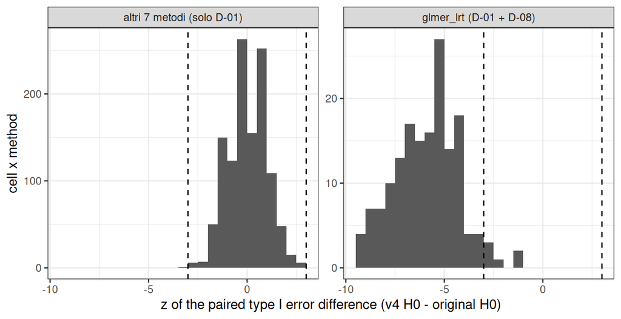

Figura 1

### Come leggere le tabelle

- **Tabella E.** Cosa guardare: la colonna “superato”. *Segnale d’errore*: un “si” la cui colonna “osservato” contraddice la tolleranza.
- **E1.** Cosa guardare: v4 differisce solo nel coefficiente testato in tutte le 18 righe; l’originale differisce in sigma (e gamma) solo in GenBinaryY M3-M5. *Segnale d’errore*: una differenza in altri argomenti, o una riga AR1 in cui cambia la D.
- **E2-E3.** Cosa guardare: beta0(T) decrescente con T e prevalenze H0 vicine a 0,5945 (0,589 in GLMM-native). *Segnale d’errore*: |z| > 3 in E3, o una prevalenza AR1 che deriva con T.
- **E4.** Cosa guardare: chunk scritti = attesi e errori di generazione solo in F2, L (AR1) e C. *Segnale d’errore*: errori in GenBinaryY o GLMM-native, dove S2 non ne aveva.
- **E5 e E5b.** Cosa guardare: la quota per M5 e la colonna “singolare” fra i discordanti; “stessi theta” = n verifica D-08. *Segnale d’errore*: un LRT con meno parametri di varianza del Wald.
- **E6 e E6b.** Cosa guardare: superamenti concentrati in `glmer_lrt`. *Segnale d’errore*: superamenti diffusi negli altri metodi.

### Attese non superate

- **Q8b** (|LRT - Wald| < 1e-3 in almeno il 95% delle coppie senza warning): non superata in 6 righe su 12 (GenBinaryY M3 0,944, M4 0,948, M5 0,608; GLMM-AR1 M5 0,760; GLMM-native M5 0,787; GenBinaryY M1c 0,950). Causa, dall’indagine E5b: i due fit sono lo stesso modello (stesso numero di parametri di varianza in 400/400, quindi D-08 e’ applicato) e le stime salvate si riproducono 400/400; le discordanze sono fit singolari (M5 60/60 nei tre meccanismi) o superfici piatte con pochi cluster (M1c), dove i due ottimizzatori si fermano in punti diversi. Nei discordanti di M5 `bobyqa` (LRT) raggiunge una log-verosimiglianza piu’ alta del Wald (ottimizzatore di default) in 28-35 casi su 60; in M1c GenBinaryY il Wald e’ piu’ alto in 32/60. Il criterio presupponeva che due ottimizzatori diversi trovassero lo stesso massimo: questo non vale per una quota non trascurabile dei fit. Conseguenza per S4 e S7: la stima del Wald `glmer` con le opzioni di default non e’ sempre al massimo della verosimiglianza di Laplace.
- **Q9** (differenza appaiata entro 3 MCSE in almeno il 99% delle combinazioni, M3-M4): I tipo 0,883, quota usabile 0,989. Causa: il confronto per `glmer_lrt` misura D-01 e D-08 insieme, perche’ in F1 il LRT usa ora le pendenze casuali; 156 dei 157 superamenti di I tipo sono di `glmer_lrt` (differenza media -0,046). Senza `glmer_lrt` i valori sono in E6b. L’attesa era formulata male: non separava i due cambiamenti. L’effetto di D-01 si legge sui 7 metodi restanti, dove resta un superamento su 1.185 (I tipo) e uno su 454 (quota usabile); lo spostamento di `glmer_lrt` e’ l’effetto di D-08 e si quantifica in S4.

## 4. Controprova

Il test che smentirebbe lo step e’ Q3 insieme a Q5: se lo schema dei semi o l’RNGkind fossero stati alterati, il banco con il codice originale non riprodurrebbe `results_full/` (300/300 bit per bit) e la `gee` rieseguita nei 12.480 chunk L non coinciderebbe con quella originale (12.480/12.480, 5.277.866 righe). La controprova degli strumenti di parita’ e’ la riga “originale” di E1: lo stesso test, sui generatori originali, trova esattamente le tre violazioni note da S1 (P2).

## Verdetto

**Chiuso.** Il rerun e’ completo (18.720/18.720 chunk, zero errori), lo schema dei semi e’ intatto (Q3, Q5), la parita’ H0/H1 vale in tutti i 18 generatori (Q1), D-02 e D-08 sono applicati (Q2, Q8a), i fallimenti sono registrati con il motivo e cadono solo sui disegni degeneri di S2 (Q6, Q7), M1c e’ calibrato come pre-registrato (Q10). Due attese non superate, decise dal PI in chat il 2026-10-17:

- **Q8b, D-16**: si dichiara in S7 che il Wald `glmer` usa le opzioni di default di lme4 e che sui fit singolari o piatti non sempre raggiunge il massimo; in S4 si aggiunge la sensibilita’ “Wald bobyqa” con stima e SE gia’ salvati nelle righe `glmer_lrt` (modello completo con bobyqa), senza nuovi run.
- **Q9, D-17**: attesa formulata male (confondeva D-01 e D-08 per `glmer_lrt`); registrata come tale. Nessun run aggiuntivo.

Requisiti Morris aggiornati in `docs/audit/MORRIS2019_conformita.csv`: B3 e B4 risolti nei dati (testo in S7), E3 risolto nei dati (registrazione dei fallimenti), D1 avanzato (struttura del LRT; opzioni del Wald da dichiarare, D-16), B6 avanzato (scenario M1c generato; confronto in S4-S7).